# Can You Break A Very Expensive Centrifuge?

## [Riddler Express](https://fivethirtyeight.com/features/can-you-break-a-very-expensive-centrifuge/)

From Quoc Tran comes a curious case of centrifugation:

Quoc’s lab has a microcentrifuge, a piece of equipment that can separate components of a liquid by spinning around very rapidly. Liquid samples are pipetted into small tubes, which are then placed in one of the microcentrifuge’s 12 slots evenly spaced in a circle.

Animation of a centrifuge with 12 slots spinning around. For the microcentrifuge to work properly, each tube must hold the same amount of liquid. Also, importantly, the center of mass of the samples must be at the very center of the circle — otherwise, the microcentrifuge will not be balanced and may break.

Quoc notices that there is no way to place exactly one tube in the microcentrifuge so that it will be balanced, but he can place two tubes (e.g., in slots 1 and 7).

Extra credit: Assuming the 12 slots are distinct, how many different balanced arrangements of seven samples are there?

## Solution

Balanced two test tube and three test tube solutions are shown below.

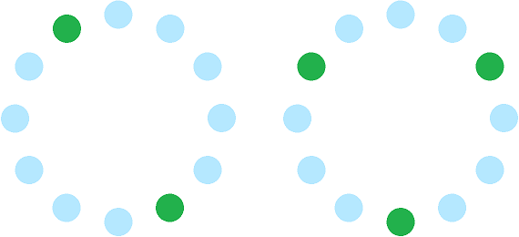

```python
from IPython.display import Image
Image(filename = '2&3.png')
```

A balanced set of five test tubes is created by combining two and three test tubes.

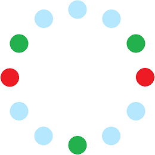

```python
Image(filename = '5.png')
```

No matter where the pair of red test tubes are placed, reorienting the setup will yield the same result as above.

A balanced set of seven test tubes is created by inverting a balanced set of five test tubes, as shown below.

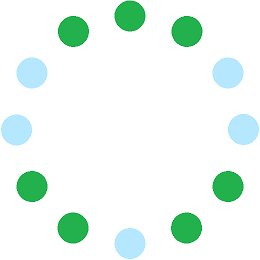

```python
Image(filename = '7.png')
```

There are 12 orientations, as any number can be in the bottom position.

1, 2, 5, 6, 8, 9, 12 is one such solution.

#### 2020.09.21